# land_cover_classification slides

GA Data Science Final Project

Land Cover Classification with Sklearn

by Anastasia Clark

Problem Definition

Land cover refers to the surface cover on the ground, whether vegetation, urban infrastructure, water, bare soil or other. Land cover maps are used primarily for land use planning, bur also increasingly for climate modeling

Some of the land use applications include:

- natural resource management
- wildlife habitat protection
- baseline mapping for GIS input
- urban expansion / encroachment
- legal boundaries for tax and property evaluation

Problem Statement

Perform land cover classification using Sentinel 2 data and Sklearn algorithms learned in class.

Land Cover Map Portland, Oregon

[figure not shown]

Remote Sensing Basics

[figure not shown]

Remote Sensing Basics

[figure not shown]

Getting and preprocessing data

```python
import pandas as pd
import os
import yaml
from sentinelsat import SentinelAPI, geojson_to_wkt
import osmnx as ox
import geopandas as gpd
import numpy as np
import matplotlib.pyplot as plt
import os
from osgeo import gdal
import rasterio
from rasterio.plot import show_hist
from rasterio.plot import show
from rasterio.mask import mask
from shapely.geometry import box
from fiona.crs import from_epsg
from shapely.geometry import box
import json
```

```python
with open("auth.yaml", 'r') as ymlfile:
    auth = yaml.safe_load(ymlfile)
```

```python
api = SentinelAPI(auth['copernicus_open_access_hub']['username'],
                  auth['copernicus_open_access_hub']['password'],
                  'https://scihub.copernicus.eu/dhus')
```

```python
place_name='Gelendzhik, Russia'
```

```python
# will return either polygon or point (in GeodatFrame format) if boundaries of the place aren't available
place = ox.gdf_from_place(place_name)
```

```python
place
```

|  | geometry | place_name | bbox_north | bbox_south | bbox_east | bbox_west |
| --- | --- | --- | --- | --- | --- | --- |
| 0 | POLYGON ((37.9666898 44.5802578, 37.9668569 44... | Gelendzhik, городской округ Геленджик, Krasnod... | 44.618823 | 44.523708 | 38.136722 | 37.96669 |

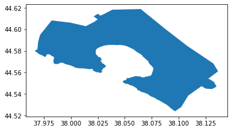

```python
place.plot()
```

```python
# 3-month period to search for scenes with less than 6% cloud coverage where bounding box of the area
# of interest is within the image (that is image contains the bounding box)
products = api.query(query_box.wkt,
                     area_relation='Contains',
                     date = ('20190601', '20190926'),
                     platformname = 'Sentinel-2',
                     processinglevel = 'Level-2A',
                     cloudcoverpercentage = (0,5))
```

```python
products_gdf_sorted.head()
```

|  | title | link | link_alternative | link_icon | summary | beginposition | endposition | ingestiondate | orbitnumber | relativeorbitnumber | ... | processingbaseline | processinglevel | producttype | platformname | size | filename | level1cpdiidentifier | identifier | uuid | geometry |
| --- | --- | --- | --- | --- | --- | --- | --- | --- | --- | --- | --- | --- | --- | --- | --- | --- | --- | --- | --- | --- | --- |
| a0355a57-a5eb-452d-a248-0bbdf44f463c | S2B_MSIL2A_20190916T082559_N0213_R021_T37TDK_2... | https://scihub.copernicus.eu/dhus/odata/v1/Pro... | https://scihub.copernicus.eu/dhus/odata/v1/Pro... | https://scihub.copernicus.eu/dhus/odata/v1/Pro... | Date: 2019-09-16T08:25:59.024Z, Instrument: MS... | 2019-09-16 08:25:59.024 | 2019-09-16 08:25:59.024 | 2019-09-16 20:24:18.384 | 13203 | 21 | ... | 02.13 | Level-2A | S2MSI2A | Sentinel-2 | 600.05 MB | S2B_MSIL2A_20190916T082559_N0213_R021_T37TDK_2... | S2B_OPER_MSI_L1C_TL_SGS__20190916T121753_A0132... | S2B_MSIL2A_20190916T082559_N0213_R021_T37TDK_2... | a0355a57-a5eb-452d-a248-0bbdf44f463c | (POLYGON ((37.74888294664043 44.15851530960486... |
| f04131c5-10a4-4321-82db-9eb7c0a6bde1 | S2B_MSIL2A_20190827T082609_N0213_R021_T37TDK_2... | https://scihub.copernicus.eu/dhus/odata/v1/Pro... | https://scihub.copernicus.eu/dhus/odata/v1/Pro... | https://scihub.copernicus.eu/dhus/odata/v1/Pro... | Date: 2019-08-27T08:26:09.024Z, Instrument: MS... | 2019-08-27 08:26:09.024 | 2019-08-27 08:26:09.024 | 2019-08-27 17:07:30.465 | 12917 | 21 | ... | 02.13 | Level-2A | S2MSI2A | Sentinel-2 | 592.07 MB | S2B_MSIL2A_20190827T082609_N0213_R021_T37TDK_2... | S2B_OPER_MSI_L1C_TL_EPAE_20190827T111401_A0129... | S2B_MSIL2A_20190827T082609_N0213_R021_T37TDK_2... | f04131c5-10a4-4321-82db-9eb7c0a6bde1 | (POLYGON ((37.74888294664043 44.15851530960486... |
| 0806a7e1-325b-40fa-9ef1-813d82ea89c5 | S2B_MSIL2A_20190903T081609_N0213_R121_T37TDK_2... | https://scihub.copernicus.eu/dhus/odata/v1/Pro... | https://scihub.copernicus.eu/dhus/odata/v1/Pro... | https://scihub.copernicus.eu/dhus/odata/v1/Pro... | Date: 2019-09-03T08:16:09.024Z, Instrument: MS... | 2019-09-03 08:16:09.024 | 2019-09-03 08:16:09.024 | 2019-09-03 17:24:45.057 | 13017 | 121 | ... | 02.13 | Level-2A | S2MSI2A | Sentinel-2 | 1016.59 MB | S2B_MSIL2A_20190903T081609_N0213_R121_T37TDK_2... | S2B_OPER_MSI_L1C_TL_EPAE_20190903T111337_A0130... | S2B_MSIL2A_20190903T081609_N0213_R121_T37TDK_2... | 0806a7e1-325b-40fa-9ef1-813d82ea89c5 | (POLYGON ((37.74888294664043 44.15851530960486... |
| c01a3c5c-5554-4015-b671-64ed4e9380a7 | S2A_MSIL2A_20190901T082601_N0213_R021_T37TDK_2... | https://scihub.copernicus.eu/dhus/odata/v1/Pro... | https://scihub.copernicus.eu/dhus/odata/v1/Pro... | https://scihub.copernicus.eu/dhus/odata/v1/Pro... | Date: 2019-09-01T08:26:01.024Z, Instrument: MS... | 2019-09-01 08:26:01.024 | 2019-09-01 08:26:01.024 | 2019-09-01 14:47:50.800 | 21897 | 21 | ... | 02.13 | Level-2A | S2MSI2A | Sentinel-2 | 597.63 MB | S2A_MSIL2A_20190901T082601_N0213_R021_T37TDK_2... | S2A_OPER_MSI_L1C_TL_SGS__20190901T103223_A0218... | S2A_MSIL2A_20190901T082601_N0213_R021_T37TDK_2... | c01a3c5c-5554-4015-b671-64ed4e9380a7 | (POLYGON ((37.74888294664043 44.15851530960486... |
| c4cfd524-135d-4163-96c8-07a89d1ea907 | S2A_MSIL2A_20190812T082611_N0213_R021_T37TDK_2... | https://scihub.copernicus.eu/dhus/odata/v1/Pro... | https://scihub.copernicus.eu/dhus/odata/v1/Pro... | https://scihub.copernicus.eu/dhus/odata/v1/Pro... | Date: 2019-08-12T08:26:11.024Z, Instrument: MS... | 2019-08-12 08:26:11.024 | 2019-08-12 08:26:11.024 | 2019-08-12 17:44:07.657 | 21611 | 21 | ... | 02.13 | Level-2A | S2MSI2A | Sentinel-2 | 593.56 MB | S2A_MSIL2A_20190812T082611_N0213_R021_T37TDK_2... | S2A_OPER_MSI_L1C_TL_SGS__20190812T121250_A0216... | S2A_MSIL2A_20190812T082611_N0213_R021_T37TDK_2... | c4cfd524-135d-4163-96c8-07a89d1ea907 | (POLYGON ((37.74888294664043 44.15851530960486... |

5 rows × 35 columns

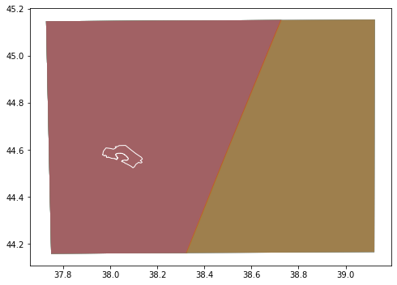

```python
ax=products_gdf_sorted.plot(column='uuid', cmap=None, alpha=0.5, figsize=(8, 8))
place.plot(ax=ax, edgecolor="white", facecolor='None');
```

```python
api.download(uuid, directory_path='./imagery')
```

```
{'id': 'a0355a57-a5eb-452d-a248-0bbdf44f463c',
 'title': 'S2B_MSIL2A_20190916T082559_N0213_R021_T37TDK_20190916T130703',
 'size': 629254856,
 'md5': 'D81389A9DA283099896F26EEEAD287D8',
 'date': datetime.datetime(2019, 9, 16, 8, 25, 59, 24000),
 'footprint': 'POLYGON((38.732885529268415 45.151802429452395,38.679186431583965 45.02150302085845,38.61930826033507 44.87593637992597,38.57165932795098 44.760002139478594,38.55912541155133 44.729568249601456,38.4992968430776 44.58417938183885,38.44122898796999 44.438424680731984,38.41487653936901 4…
 'url': "https://scihub.copernicus.eu/dhus/odata/v1/Products('a0355a57-a5eb-452d-a248-0bbdf44f463c')/$value",
 'Online': True,
 'Creation Date': datetime.datetime(2019, 9, 16, 20, 25, 14, 987000),
 'Ingestion Date': datetime.datetime(2019, 9, 16, 20, 24, 18, 384000),
 'path': './imagery/S2B_MSIL2A_20190916T082559_N0213_R021_T37TDK_20190916T130703.zip',
 'downloaded_bytes': 629254856}
```

[figure not shown]

Band designations are found here: https://www.usgs.gov/centers/eros/science/usgs-eros-archive-sentinel-2?qt-science_center_objects=0#qt-science_center_objects

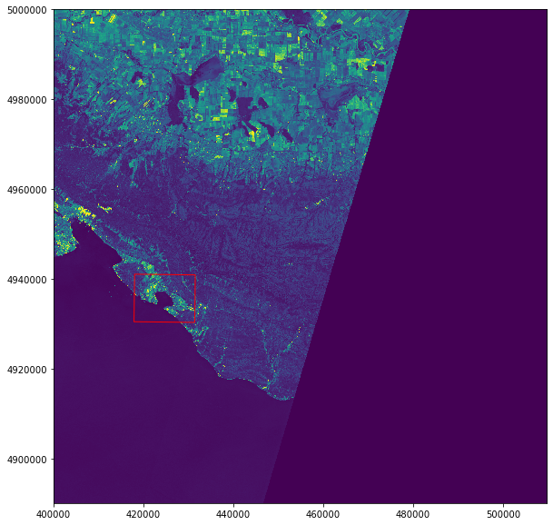

```python
# Vizualize the raster band and the area of interest
fig, ax = plt.subplots(figsize=(10, 10))
plt.imshow(data, extent=[src.bounds.left, src.bounds.right, src.bounds.bottom, src.bounds.top])
geo_box.to_crs(src.crs).plot(ax=plt.gca(), edgecolor="red", facecolor="none");
```

Data Preprocessing

```python
def crop_band(clip_gdf, input_folder, band, output_folder, out_name):
    if not os.path.exists(output_folder):
        os.makedirs(output_folder)
    crop_feature = [json.loads(clip_gdf.to_json())['features'][0]['geometry']]
    src=rasterio.open(os.path.join(input_folder, band))
    out_image, out_transform=mask(src, crop_feature, crop=True)
    out_meta=src.meta.copy()
    out_meta.update({'height': out_image.shape[1],
                   'width':out_image.shape[2],
                   'transform': out_transform})

    with rasterio.open(f'{output_folder}/{out_name}.tif', 'w', **out_meta) as dest:
        dest.write(out_image)
```

- Resulted clipped bands have 537 rows and 682 columns

Feature generation to add additional dimension

Normalized Difference Vegetation Index (NDVI) quantifies vegetation by measuring the difference between near-infrared (which vegetation strongly reflects) and red light (which vegetation absorbs). NDVI always ranges from -1 to +1. But there isn’t a distinct boundary for each type of land cover.

For example, when you have negative values, it’s highly likely that it’s water.

On the other hand, if you have a NDVI value close to +1, there’s a high possibility that it’s dense green leaves.

But when NDVI is close to zero, there isn’t green leaves and it could even be an urbanized area.

https://gisgeography.com/ndvi-normalized-difference-vegetation-index/

$NDVI=\frac{NIR-RED}{NIR+RED}$

```python
# write the function to calculate NDVI
def calculate_ndvi(red, nir):
    ''' Given Red and NIR bands as input,
    calcuates NDVI'''

    # beacase division will unlikely result in integers
    # change the datatype of our arrays from integer to float
    red=red.astype(float)
    nir=nir.astype(float)

    # since we have 0 values
    # we need to mask them out, so that they don't participate in the calculations
    masked_red=np.ma.masked_where(red==0, red)
    masked_nir=np.ma.masked_where(nir==0, nir)

    # NDVI formula
    ndvi=(masked_nir-masked_red)/(masked_nir+masked_red)
    ndvi=ndvi.filled(fill_value=-1)
    return ndvi
```

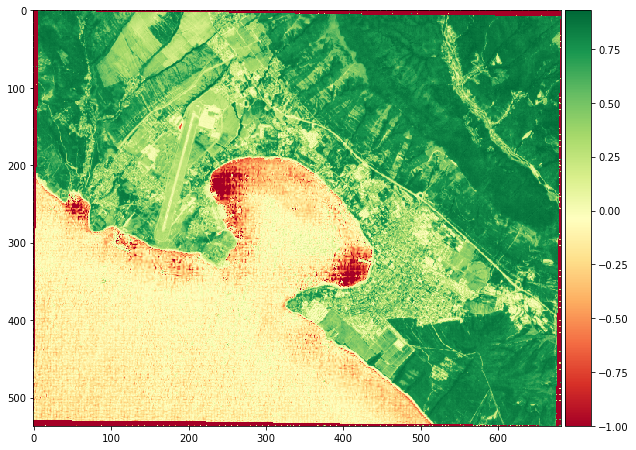

```python
fig, ax = plt.subplots(figsize=(10, 10))
im=plt.imshow(ndvi, cmap=plt.get_cmap('RdYlGn'))
divider = make_axes_locatable(ax)
cax = divider.append_axes("right", size="5%", pad=0.05)
plt.colorbar(im, cax=cax);
```

Usupervised Classification

```python
from sklearn import cluster
```

```python
all_bands=np.dstack([red.ravel(),
                     green.ravel(),
                     blue.ravel(),
                     nir.ravel(),
                     ndvi.ravel(),
                     band5.ravel(),
                     band6.ravel(),
                     band7.ravel()])
```

```python
# 537 x 682 = 366234
all_bands.shape[1:]
```

```
(366234, 8)
```

```python
X = all_bands.reshape(all_bands.shape[1:])
```

```python
k_means = cluster.KMeans(n_clusters=6, random_state=123)
k_means.fit(X)
```

```
KMeans(algorithm='auto', copy_x=True, init='k-means++', max_iter=300,
       n_clusters=6, n_init=10, n_jobs=None, precompute_distances='auto',
       random_state=123, tol=0.0001, verbose=0)
```

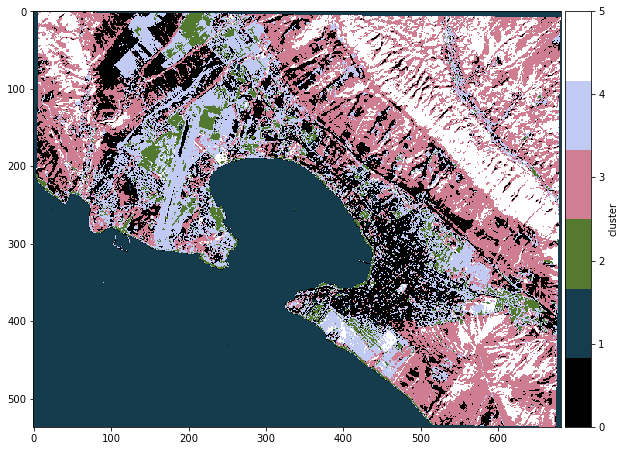

```python
plt.figure(figsize=(10, 10))
ax = plt.gca()
im=plt.imshow(X_cluster, cmap=plt.cm.get_cmap('cubehelix', 6))
divider = make_axes_locatable(ax)
cax = divider.append_axes("right", size="5%", pad=0.05)
plt.colorbar(ticks=range(6), label='cluster', cax=cax)
plt.show()
```

[figure not shown]

```python
fig, ax = plt.subplots(figsize=(11, 11))
ax.imshow(image, interpolation='nearest')
plt.tight_layout()
```

Assign Cluster Labels

```python
labels={
    3: 'trees/dense vegetation',
    1: 'water',
    0: 'residential/roads',
    4: 'grassland',
    2: 'commercial/industrial',
    5: 'sparse vegetaion' ,
}
```

Supervised Classification

```python
bands_df=pd.DataFrame(X, columns=['red', 'green', 'blue', 'nir', 'ndvi', 'band5', 'band6', 'band7'])
```

```python
bands_df['cluster'] = k_means.labels_
```

```python
bands_df['labels']=bands_df['cluster'].map(labels)
```

```python
bands_df.sample(20)
```

|  | red | green | blue | nir | ndvi | band5 | band6 | band7 | cluster | labels |
| --- | --- | --- | --- | --- | --- | --- | --- | --- | --- | --- |
| 79470 | 781.0 | 642.0 | 436.0 | 2129.0 | 0.463230 | 1166.0 | 1673.0 | 1847.0 | 0 | residential/roads |
| 288921 | 1673.0 | 1459.0 | 1246.0 | 2745.0 | 0.242644 | 1997.0 | 2223.0 | 2432.0 | 4 | grassland |
| 46417 | 412.0 | 485.0 | 277.0 | 2450.0 | 0.712089 | 1056.0 | 1883.0 | 2145.0 | 3 | trees/dense vegetation |
| 22274 | 282.0 | 383.0 | 241.0 | 2816.0 | 0.817947 | 707.0 | 2028.0 | 2340.0 | 3 | trees/dense vegetation |
| 344325 | 432.0 | 519.0 | 290.0 | 2720.0 | 0.725888 | 1106.0 | 2096.0 | 2383.0 | 3 | trees/dense vegetation |
| 168823 | 54.0 | 276.0 | 309.0 | 36.0 | -0.200000 | 34.0 | 44.0 | 51.0 | 1 | water |
| 255889 | 64.0 | 146.0 | 228.0 | 50.0 | -0.122807 | 58.0 | 57.0 | 59.0 | 1 | water |
| 107727 | 180.0 | 322.0 | 159.0 | 3102.0 | 0.890311 | 634.0 | 2168.0 | 2723.0 | 3 | trees/dense vegetation |
| 2309 | 0.0 | 0.0 | 0.0 | 0.0 | -1.000000 | 0.0 | 0.0 | 0.0 | 1 | water |
| 286032 | 55.0 | 140.0 | 231.0 | 58.0 | 0.026549 | 46.0 | 51.0 | 53.0 | 1 | water |
| 334851 | 513.0 | 535.0 | 301.0 | 2765.0 | 0.687004 | 1077.0 | 1860.0 | 2298.0 | 3 | trees/dense vegetation |
| 166252 | 206.0 | 359.0 | 158.0 | 2157.0 | 0.825645 | 699.0 | 1700.0 | 1943.0 | 0 | residential/roads |
| 163260 | 49.0 | 395.0 | 415.0 | 21.0 | -0.400000 | 30.0 | 10.0 | 23.0 | 1 | water |
| 326059 | 66.0 | 148.0 | 235.0 | 37.0 | -0.281553 | 38.0 | 46.0 | 52.0 | 1 | water |
| 350583 | 40.0 | 139.0 | 219.0 | 34.0 | -0.081081 | 32.0 | 32.0 | 29.0 | 1 | water |
| 2411 | 0.0 | 0.0 | 0.0 | 0.0 | -1.000000 | 0.0 | 0.0 | 0.0 | 1 | water |
| 126668 | 383.0 | 611.0 | 286.0 | 3542.0 | 0.804841 | 1135.0 | 2760.0 | 3212.0 | 5 | sparse vegetaion |
| 268497 | 1150.0 | 1012.0 | 889.0 | 1329.0 | 0.072207 | 1108.0 | 1212.0 | 1398.0 | 0 | residential/roads |
| 308264 | 0.0 | 0.0 | 3.0 | 3.0 | -1.000000 | 1.0 | 0.0 | 1.0 | 1 | water |
| 127563 | 354.0 | 402.0 | 240.0 | 2298.0 | 0.733032 | 839.0 | 1647.0 | 1977.0 | 0 | residential/roads |

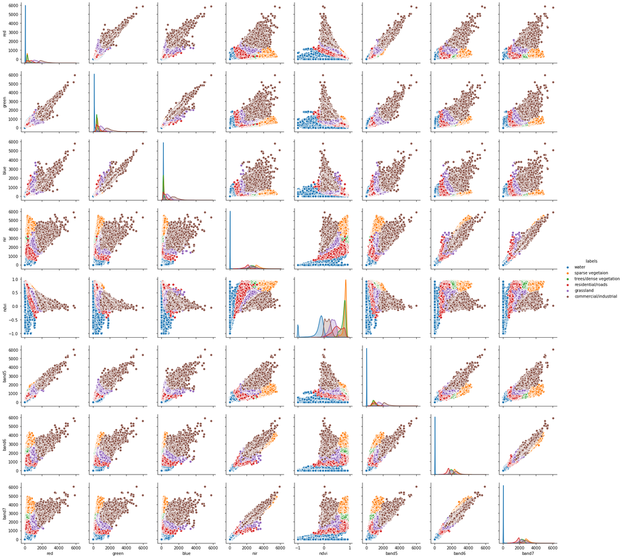

```python
sns.pairplot(bands_df.drop('cluster', 1), hue="labels")
plt.show()
```

Model Optimization

```python
grid_params={'n_neighbors': list(range(3, 50, 4)),
             'weights': ['uniform', 'distance'],
             'metric': ['euclidean', 'manhattan']
}
```

```python
gs_results=gs.fit(X_train, y_train)
```

```
Fitting 3 folds for each of 48 candidates, totalling 144 fits
```

```
[Parallel(n_jobs=-1)]: Using backend LokyBackend with 4 concurrent workers.
[Parallel(n_jobs=-1)]: Done  42 tasks      | elapsed:  3.3min
[Parallel(n_jobs=-1)]: Done 144 out of 144 | elapsed: 18.5min finished
```

```python
gs_results.best_score_
```

```
0.9930608901428961
```

```python
gs_results.best_params_
```

```
{'metric': 'manhattan', 'n_neighbors': 39, 'weights': 'distance'}
```

Optimal KNN Model

```python
# now train the model using the best parameters returned by Gridsearch
optimal_knn=KNeighborsClassifier(n_neighbors=gs_results.best_params_['n_neighbors'],
                        weights=gs_results.best_params_['weights'],
                        metric=gs_results.best_params_['metric'])
```

```python
metrics.accuracy_score(y_test, y_pred)
```

```
0.9934905361570135
```

Training score was 0.9930608901428961

Model Performance

```python
styled_df
```

| label | TN | FP | FN | TP |
| --- | --- | --- | --- | --- |
| residential/roads | 78272 | 153 | 131 | 13003 |
| water | 60122 | 4 | 15 | 31418 |
| commercial/industrial | 88399 | 28 | 37 | 3095 |
| trees/dense vegetation | 70295 | 201 | 176 | 20887 |
| grassland | 79590 | 143 | 101 | 11725 |
| sparse vegetaion | 80521 | 67 | 136 | 10835 |

```python
print(classification_report(y_test, y_pred))
```

```
              precision    recall  f1-score   support

           0       0.99      0.99      0.99     13134
           1       1.00      1.00      1.00     31433
           2       0.99      0.99      0.99      3132
           3       0.99      0.99      0.99     21063
           4       0.99      0.99      0.99     11826
           5       0.99      0.99      0.99     10971

    accuracy                           0.99     91559
   macro avg       0.99      0.99      0.99     91559
weighted avg       0.99      0.99      0.99     91559
```

Limitations and Future Work

- Model will not be abble to predict classes it hasn't been trained on
- Additional data with images around different geographical areas and different seasons will make the model more robust
- Adding additinal bands and features (ex: NDWI and NDSI) will help with distinguishing other closely-related land cover classes